## Project 2

*Enter your name and EID here*

This is the dataset you will be working with:

```r
wine_features <-
  read_csv("https://wilkelab.org/classes/SDS348/data_sets/wine_features.csv") %>%
  mutate(type = as.factor(type))
```

### **Part 1**

**Question:** Can red and white wines be distinguished based on their physicochemical composition?

To answer this question, perform a principal component analysis. Make a scatterplot of PC2 vs. PC1, and a rotation matrix visualizing the influence of the input variables. *Hint: You must remove all categorical variables before creating the PCA object.*

**Introduction:** The dataset `wine_features` contains 6497 rows describing various chemical attributes of red and white wine (indicated by the `type` column) and each wine’s relative quality (indicated by the `quality`/`quality_grade` column) on a scale of 3 to 9 as graded by experts performing a blind taste test. Chemical attributes recorded for each wine include `fixed_acidity`, `volatile_acidity`, `citric_acid`, `residual_sugar`, `chlorides`, `free_sulfur_dioxide`, `total_sulfur_dioxide`, `density`, `pH`, `sulphates`, `alcohol`. Categorical descriptions of alcohol content and acidity are given by `alcohol_grade` and `acidity_grade`.

**Approach:** First, I will remove all non-numerical columns from the dataset (`type`, `quality_grade`, `alcohol_grade`, and `acidity_grade`). Then, I will perform a PCA on the remaining numerical columns using the functions `scale()` and `prcomp()`, and save the results in a new dataframe called `pca_data`. To evaluate whether the physicochemical properties describe the type of wine, I’ll make a scatterplot (using `geom_point()`) comparing the first and second principal components, coloring each point by type of wine. Then, I’ll make a new dataframe containing the rotation matrix and visualize the rotation matrix using `geom_segment()` and `geom_text_repel()`.

**Analysis:**

```r
# perform PCA on `wine_features` dataset
pca <- wine_features %>%
  select(-type, -quality_grade,
         -alcohol_grade, -acidity_grade) %>%
  scale() %>%
  prcomp()

# get transformation data from PCA object for further analysis
pca_data <- data.frame(pca$x, wine_features)
```

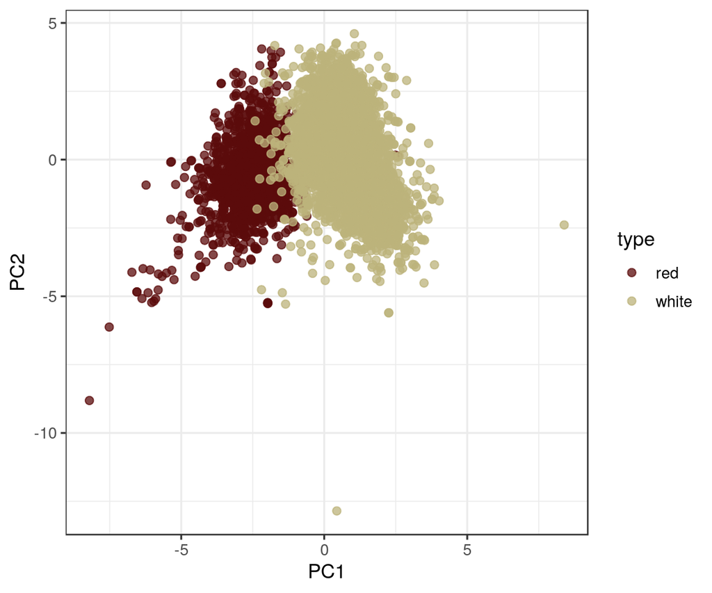

```r
# color PC2 vs. PC1 scatterplot by type of wine
ggplot(pca_data, aes(x = PC1, y = PC2, color = type)) +
  geom_point(alpha = 0.75, size = 2) +
  scale_color_manual(values = c(wine_palette[5], wine_palette[1]))
```

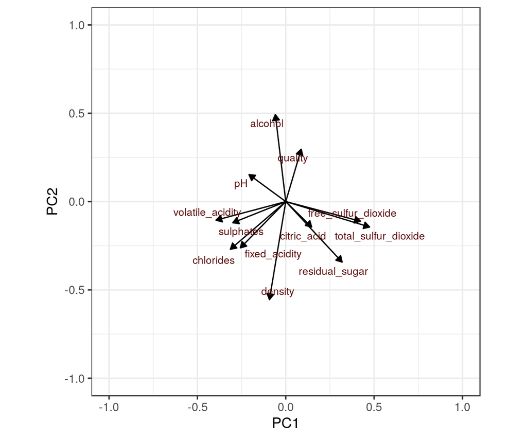

```r
# capture the rotation matrix in a data frame
rotation_data <- data.frame(pca$rotation,
                            variable = row.names(pca$rotation))

# define a pleasing arrow style
arrow_style <- arrow(length = unit(0.075, "inches"),
                     type = "closed")

# now plot, using geom_segment() for arrows and geom_text for labels
ggplot(rotation_data) +
  geom_segment(aes(xend = PC1, yend = PC2),
               x = 0, y = 0,
               arrow = arrow_style) +
  geom_text_repel(aes(x = PC1, y = PC2, label = variable),
                  size = 3,
                  color = wine_palette[5],
                  #vjust = 0,
                  segment.size = 0,
                  set.seed(13)) +
  xlim(-1., 1.) +
  ylim(-1., 1.) +
  coord_fixed() # fix aspect ratio to 1:1
```

**Discussion:** From the scatter plot of principal-component space calculated from the `wine_features` dataset, we can see the two wine types separate into distinct groupings on the plot, i.e., a significant amount of the variation in the data is described by the two wine types (`type`). Wine types are separated largely by PC1 such that red wines generally have negative PC1 values and white wines have positive PC1 values. Thus, it’s likely red and white wines have highly distinct physicochemical profiles.

Visualization of the rotation matrix indicates that variables describing sulfur content (`free_sulfur_dioxide`, `total_sulfur_dioxide`, `sulphates`) and acidity (`volatile_acidity`, `fixed_acidity`, `chlorides`) are captured by PC1, while `density`, `alcohol` content, and `quality` largely contribute to PC2. The variable `residual_sugar` is captured by both PC1 and PC2. Since `volatile_acidity` contributes mostly to negative PC1 space, we can conclude red wines have higher values of acetic acid. Similarly, since ``free_sulfur_dioxide` and `total_sulfur_dioxide` contribute mostly to positive PC1 space, we can conclude that white wines have higher amounts of free and bound SO2.